# Credict Card Usage Behaviour

Victor Nugraha

July 21, 2022

```r
# clear-up the environment
rm(list = ls())

# chunk options
knitr::opts_chunk$set(
  message = FALSE,
  warning = FALSE,
  fig.align = "center",
  comment = "#>"
)

# scientific notation
options(scipen = 9999)
```

# 1 Pendahuluan

Materi ini diproduksi oleh tim dari Algoritma untuk *DDE - Bank OCBC NISP* . Materi berikut hanya ditujukan untuk kalangan terbatas, meliputi individu/personal yang menerima materi ini secara langsung dari lembaga pelatihan. Materi ini dilarang untuk direproduksi, didistribusikan, diterjemahkan, atau diadaptasikan dalam bentuk apapun di luar izin dari individu dan organisasi yang berkepentingan.

**Algoritma** adalah pusat pendidikan Data Science di Jakarta. Kami mengadakan workshop dan program pelatihan untuk membantu para profesional dan pelajar untuk mendapatkan keahlian dalam berbagai bidang dalam ruang lingkup Data Science: data visualization, machine learning, data modeling, statistical inference, dan lain-lainnya.

Sebelum masuk ke dalam materi dan menjalankan kode-kode di dalam materi ini, silakan anda melihat bagian **Library and Setup** untuk melihat dan memastikan semua persyaratan dasar untuk mengikuti materi ini sudah terpenuhi termasuk package-package yang diperlukan. Pada bagian **Tujuan Pembelajaran** anda dapat melihat secara umum apa saja yang akan dipelajari dalam modul materi ini. Kami harap materi ini akan bermanfaat bagi karir ataupun menambah keahlian peserta.

## 1.1 Tujuan Pembelajaran

Tujuan utama dari workshop ini adalah untuk memberikan pengenalan yang komprehensif mengenai tools dan perangkat lunak yakni sebuah open-source *R Programming* yang digunakan untuk melakukan sekementasi kustomer dengan menggunakan dari *Unsupervised Machine Learning - Clustering*. Adapun materi ini akan mencakup:

- Persiapan Data
  - Membaca Data
  - Memproses dan manipulasi data agar dapat dieksplorasi/Data Wrangling
- Eksplorasi Data
  - Eksplorasi data secara statistika deskriptif
  - Eksplorasi data secara visualisasi
- Unsupervised Machine Learning
  - Persiapan clustering
  - Clustering dengan K-Medoids
  - Interpretasi hasil clustering

# 2 Topik bisnis: Customer Segmentation Based On Credit Card Usage Behaviour

Dengan berbagai macam fitur maupun promo yang ditawarkan kepada pengguna kartu kredit, banyak sekali individu yang mulai membuat kartu kredit untuk mempermudah proses transaksi yang dilakukan dan mendapatkan promo menarik.

Untuk dapat bersaing antara Bank dalam mengait calon pengguna kartu kredit, kita harus dapat menawarkan jenis kartu kredit yang sesuai dengan kebutuhan dari calon pelanggan kita. Selain mengait para pengguna baru, kita juga harus menjaga bahkan meningkatkan retensi pelanggan dengan cara memberikan promo yang lebih tepat sasaran.

Dalam melakukan kedua hal tersebut tidaklah mudah karena setiap pengguna kartu kredit memiliki karakteristik yang berbeda-beda. Walaupun berbeda-beda, setiap customer dapat dikelompokan dengan karakteristik yang mendekati satu dengan lainnya sehingga nantinya dapat beberapa kelompok yang memiliki karakteristik yang mendekati. Dengan mempelajari setiap karakteristik dari setiap kelompok, kita dapat menarik kesimpulan untuk menentukan strategi bisnis untuk meningkatkan pengguna baru dan meningkatkan kepuasan dari pengguna lama.

## 2.1 Library

```r
# Data Wrangling
library(tidyverse)
library(Hmisc)

# Machine Learning - Clustering
library(cluster)
library(factoextra)

# Visualization
library(Rtsne)
```

## 2.2 Persiapan Data

### 2.2.1 Membaca Dataset

Data yang kita gunakan adalah data behavior dari para pengguna kartu kredit disebuah bank. Data tersebut kami letakan di foder `data` dengan nama file `creditcard_customer_behavior.csv`, fungsi yang dapat dimanfaatkan untuk membaca data adalah `read.csv()``

```r
# Membaca data
customer <- read.csv("data/creditcard_customer_behavior.csv")

# Menampilkan 6 data paling atas
customer %>%
  head()
```

|  | CLIENTNUM | Customer_Age | Gender | Education_Level | Marital_Status | Income_Category | Months_Inactive_12_mon | Credit_Limit | Total_Trans_Amt | Total_Trans_Ct |
| --- | --- | --- | --- | --- | --- | --- | --- | --- | --- | --- |
| 1 | 768805383 | 45 | M | High School | Married | $60K - $80K | 1 | 12691 | 1144 | 42 |
| 2 | 818770008 | 49 | F | Graduate | Single | Less than $40K | 1 | 8256 | 1291 | 33 |
| 3 | 713982108 | 51 | M | Graduate | Married | $80K - $120K | 1 | 3418 | 1887 | 20 |
| 4 | 769911858 | 40 | F | High School | Unknown | Less than $40K | 4 | 3313 | 1171 | 20 |
| 5 | 713061558 | 44 | M | Graduate | Married | $40K - $60K | 1 | 4010 | 1088 | 24 |
| 6 | 818906208 | 32 | M | High School | Unknown | $60K - $80K | 2 | 29081 | 1538 | 36 |

Deskripsi singkat:

- `CLIENTNUM`: Unique ID Client
- `Customer_Age`: Umur customer
- `Gender`: gender customer
- `Education_Level`: Tingkat pendidikan
- `Marital_Status`: Status Pernikahan
- `Income_Category`: Range pendapatan
- `Months_Inactive_12_mon`: Selama 12 bulan terakhir sempat tidak menggunakan kartu kredit berapa lama
- `Credit_Limit`: Limmit dari creditcard
- `Total_Trans_Amt`: Jumlah amount transaksi yang dilakukan selama 12 bulan terakhir
- `Total_Trans_Ct`: Total transaksi yang dilakukan selama 12 bulan terakhir

*Additional Info:*

Kita dapat membaca berbagai macam tipe file data di R, berikut adalah beberapa contoh file yang dapat kita baca di R.

- .Rds: File dalam format R.
- .csv: File dalam format csv(comma seperated value).
- .xlsx: File dalam formal excel.

Selain membaca data yang sudah tersimpan dalam komputer kita, R Studio juga dapat kita sambungkan ke database untuk mengambil data-data yang tersimpan pada database tersebut.

### 2.2.2 Data Wrangling

*Wrangling 1:* Apakah kolom `CLIENTNUM`?

- Opsi 1: Kolom `CLIENTNUM` dapat kita buang karena nantinya dapat mempengaruhi perhitungan dan pembuatan kelompok.

Untuk melakukan hal tersebut kita bisa menggunakan fungsi `select()`

```r
customer %>%
  select(-CLIENTNUM)
```

| Customer_Age | Gender | Education_Level | Marital_Status | Income_Category | Months_Inactive_12_mon | Credit_Limit | Total_Trans_Amt | Total_Trans_Ct |
| --- | --- | --- | --- | --- | --- | --- | --- | --- |
| 45 | M | High School | Married | $60K - $80K | 1 | 12691.0 | 1144 | 42 |
| 49 | F | Graduate | Single | Less than $40K | 1 | 8256.0 | 1291 | 33 |
| 51 | M | Graduate | Married | $80K - $120K | 1 | 3418.0 | 1887 | 20 |
| 40 | F | High School | Unknown | Less than $40K | 4 | 3313.0 | 1171 | 20 |
| 44 | M | Graduate | Married | $40K - $60K | 1 | 4010.0 | 1088 | 24 |
| 32 | M | High School | Unknown | $60K - $80K | 2 | 29081.0 | 1538 | 36 |
| 48 | M | Graduate | Single | $80K - $120K | 3 | 11656.0 | 1441 | 32 |
| 56 | M | College | Single | $80K - $120K | 6 | 11751.0 | 1539 | 17 |
| 35 | M | Graduate | Unknown | $60K - $80K | 1 | 8547.0 | 1311 | 33 |
| 57 | F | Graduate | Married | Less than $40K | 2 | 2436.0 | 1570 | 29 |

[output cut: 6329 more lines]

- Opsi 2: Kolom `CLIENTNUM` dapat kita buat sebagai rownames saja.

Untuk melakukan hal tersebut kita bisa menggunakan fungsi `column_to_rownames()`

```r
customer %>%
  column_to_rownames("CLIENTNUM")
```

|  | Customer_Age | Gender | Education_Level | Marital_Status | Income_Category | Months_Inactive_12_mon | Credit_Limit | Total_Trans_Amt | Total_Trans_Ct |
| --- | --- | --- | --- | --- | --- | --- | --- | --- | --- |
| 768805383 | 45 | M | High School | Married | $60K - $80K | 1 | 12691.0 | 1144 | 42 |
| 818770008 | 49 | F | Graduate | Single | Less than $40K | 1 | 8256.0 | 1291 | 33 |
| 713982108 | 51 | M | Graduate | Married | $80K - $120K | 1 | 3418.0 | 1887 | 20 |
| 769911858 | 40 | F | High School | Unknown | Less than $40K | 4 | 3313.0 | 1171 | 20 |
| 713061558 | 44 | M | Graduate | Married | $40K - $60K | 1 | 4010.0 | 1088 | 24 |
| 818906208 | 32 | M | High School | Unknown | $60K - $80K | 2 | 29081.0 | 1538 | 36 |
| 719661558 | 48 | M | Graduate | Single | $80K - $120K | 3 | 11656.0 | 1441 | 32 |
| 710599683 | 56 | M | College | Single | $80K - $120K | 6 | 11751.0 | 1539 | 17 |
| 816082233 | 35 | M | Graduate | Unknown | $60K - $80K | 1 | 8547.0 | 1311 | 33 |
| 712396908 | 57 | F | Graduate | Married | Less than $40K | 2 | 2436.0 | 1570 | 29 |

[output cut: 6329 more lines]

```r
# Menyimpan hasilnya ke dalam sebuah objek baru
customer_clean <- customer %>%
  column_to_rownames("CLIENTNUM")
```

*Wrangling 2:* Apakah terdapat kolom yang belum sesuai tipe datanya?

Untuk mengetahui apakah ada tipe data yang belum sesuai kita dapat menggunakan fungsi `glimpse()`.

```r
customer %>%
  glimpse()
```

```
#> Rows: 6,339
#> Columns: 10
#> $ CLIENTNUM              <int> 768805383, 818770008, 713982108, 769911858, 713…
#> $ Customer_Age           <int> 45, 49, 51, 40, 44, 32, 48, 56, 35, 57, 48, 61,…
#> $ Gender                 <chr> "M", "F", "M", "F", "M", "M", "M", "M", "M", "F…
#> $ Education_Level        <chr> "High School", "Graduate", "Graduate", "High Sc…
#> $ Marital_Status         <chr> "Married", "Single", "Married", "Unknown", "Mar…
#> $ Income_Category        <chr> "$60K - $80K", "Less than $40K", "$80K - $120K"…
#> $ Months_Inactive_12_mon <int> 1, 1, 1, 4, 1, 2, 3, 6, 1, 2, 2, 2, 2, 3, 2, 1,…
#> $ Credit_Limit           <dbl> 12691.0, 8256.0, 3418.0, 3313.0, 4010.0, 29081.…
#> $ Total_Trans_Amt        <int> 1144, 1291, 1887, 1171, 1088, 1538, 1441, 1539,…
#> $ Total_Trans_Ct         <int> 42, 33, 20, 20, 24, 36, 32, 17, 33, 29, 27, 30,…
```

Intuisi dari masing-masing tipe data:

- `int`: *integer*, merupakan tipe data yang diperuntuhkan untuk data-data numerik tanpa koma.
- `dbl`: *double*, merupakan tipe data yang serupa dengan integer akan tetapi data-data numerik ini bisa memiliki unsur koma/desimal.
- `chr`: *character*, merupakan tipe data yang diperuntuhkan untuk data-data alfabetikal
- `fct`: *factor*, merupakan tipe data yang diperuntuhkan untuk data-data alfabetikal yang sifatnya berulang-ulang.
- `lgl`: *logical*, merupan tipe data yang berisikan nilai TRUE atau FALSE saja.

Berdasarkan intuisi dari masing-masing tipe data, terdapat beberapa kolom yang belum sesuai:

- `Gender` -> Factor
- `Education_Level` -> Factor
- `Marital_Status` -> Factor
- `Income_Category` -> Factor

Untuk mengubah beberapa kolom di atas menjadi tipe yang lebih sesuai, kita dapat memanfaatkan fungsi `mutate()`. Contoh penggunaan fungsi mutate(): `mutate(nama_kolom = fungsi_untuk_mengubah_tipe_data(nama_kolom))`.

- `as.factor()` -> untuk mengubah tipe data menjadi factor
- `as.integer()` -> untuk mengubah tipe data menjadi integer
- `as.character` -> untuk mengubah tipe data menjadi character

Setelah mengetahui bagaimana cara mengubah tipe data, mari kita coba implementasikan.

```r
customer_clean <- customer_clean %>%
  mutate(Gender = as.factor(Gender),
         Education_Level = as.factor(Education_Level),
         Marital_Status = as.factor(Marital_Status),
         Income_Category = as.factor(Income_Category))
```

```r
customer_clean %>%
  glimpse()
```

```
#> Rows: 6,339
#> Columns: 9
#> $ Customer_Age           <int> 45, 49, 51, 40, 44, 32, 48, 56, 35, 57, 48, 61,…
#> $ Gender                 <fct> M, F, M, F, M, M, M, M, M, F, M, M, M, F, M, F,…
#> $ Education_Level        <fct> High School, Graduate, Graduate, High School, G…
#> $ Marital_Status         <fct> Married, Single, Married, Unknown, Married, Unk…
#> $ Income_Category        <fct> $60K - $80K, Less than $40K, $80K - $120K, Less…
#> $ Months_Inactive_12_mon <int> 1, 1, 1, 4, 1, 2, 3, 6, 1, 2, 2, 2, 2, 3, 2, 1,…
#> $ Credit_Limit           <dbl> 12691.0, 8256.0, 3418.0, 3313.0, 4010.0, 29081.…
#> $ Total_Trans_Amt        <int> 1144, 1291, 1887, 1171, 1088, 1538, 1441, 1539,…
#> $ Total_Trans_Ct         <int> 42, 33, 20, 20, 24, 36, 32, 17, 33, 29, 27, 30,…
```

*Wrangling 3:* Apakah terdapat missing value?

Untuk melihat apakah terdapat missing value pada data yang kita gunakan, kita dapat menggunakan fungsi `anyNA()`.

```r
customer_clean %>%
  anyNA()
```

```
#> [1] FALSE
```

Jika hasil dari fungsi adalah *FALSE*, maka tidak ada nilai missing pada data kita.

## 2.3 Eksplorasi Data Analysis

Pada tahapan eksplorasi data, kita akan mencoba untuk lebih mengenali data yang kita miliki.

*EDA 1:* Eksplorasi data dengan memanfaatkan statistika deskriptif

Statistika deskriptif dapat juga disebut sebuah eksplorasi data dengan melihat hasil dari *6 number summary* (minimal, maksimum, mean, median, 1st quartile & 3rd quartile). Fungsi yang dapat kita gunakan adalah `summary()`.

```r
customer_clean %>%
  summary()
```

```
#>   Customer_Age   Gender        Education_Level  Marital_Status
#>  Min.   :26.00   F:3008   College      : 905   Divorced: 455
#>  1st Qu.:41.00   M:3331   Doctorate    : 381   Married :2986
#>  Median :46.00            Graduate     :2796   Single  :2436
#>  Mean   :46.28            High School  :1788   Unknown : 462
#>  3rd Qu.:52.00            Post-Graduate: 469
#>  Max.   :73.00
#>        Income_Category Months_Inactive_12_mon  Credit_Limit   Total_Trans_Amt
#>  $120K +       : 488   Min.   :0.000          Min.   : 1438   Min.   :  510
#>  $40K - $60K   :1272   1st Qu.:2.000          1st Qu.: 2523   1st Qu.: 2109
#>  $60K - $80K   : 997   Median :2.000          Median : 4327   Median : 3863
#>  $80K - $120K  :1099   Mean   :2.343          Mean   : 8490   Mean   : 4396
#>  Less than $40K:2483   3rd Qu.:3.000          3rd Qu.:10588   3rd Qu.: 4751
#>                        Max.   :6.000          Max.   :34516   Max.   :17995
#>  Total_Trans_Ct
#>  Min.   : 10.00
#>  1st Qu.: 44.00
#>  Median : 67.00
#>  Mean   : 64.56
#>  3rd Qu.: 81.00
#>  Max.   :132.00
```

Insight:

- Salah satu hal yang cukup menarik adalah kebanyakan customer kita memiliki pendapatan dibawah 40 ribu USD per tahunnya.
- Insight mengenai kebanyakan customer memiliki pendapatan dibawah 40 ribut USD per tahunnya mungkin dapat dikorelasikan atau mungkin dapat divalidasi dengan tingkat pendidikan karena kebanyakan dari customer kita memiliki tingkat pendidikan di tingkat High School & Graduate.
- Dari kolom yang mewakili berapa lama customer kita tidak menggunakan kartu kredit dapat dilihat bahwa rata-rata berada di angka 2 bulan akan tetapi terdapat nilai maksimal yaitu sampai dengan 6 bulan.

Jika dirasa dengan menggunakan perhitungan statistika kita masih belum mendapatkan kesimpulan yang memuaskan, kita juga dapat melakukan analisa dengan menggunakan bantuan visualisasi. Selain itu, kita juga akan melakukan analisa yang lebih detail lagi untuk beberapa insight yang sudah kita dapatkan.

*EDA 2:* Eksplorasi data dengan memanfaatkan visualisasi

Sebagai tambahan untuk data dengan tipe numerik kita bisa melakukan visualiasi dengan plot histogram untuk melihat jumlah observasinya. Untuk melelihatnya dengan visualisasi histogram, kita tidak perlu membuatnya satu per satu, melainkan kita bisa menggunakan fungsi `hist.data.frame()` dari `library(Hmisc)`.

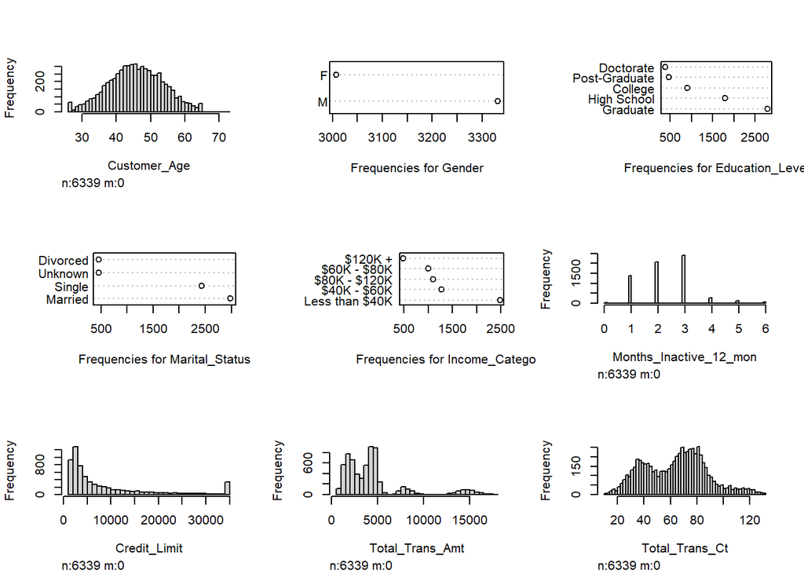

```r
customer_clean %>%
  hist.data.frame()
```

Insight

- Dari hasil visualisasi histogram pada bagian Credit Limit, kita dapat mengetahui bahwa mayoritas customer kita memiliki limit dibawah 5000USD dan semakin tinggi limitnya, semakin sedikit juga penggunanya. Akan tetapi, tedapat peningkatan jumlah pengguna kartu kredit ketika limitnya mencari di angka 33-35 ribu USD.
- Dari hasil visualisasi histrogram pada bagian berapa lama customer kita tidak menggunakan kartu kredit, terdapat kabar baik bahwa tidak terlalu banyak customer kita yang tidak menggunakan kartu kreditnya sampai dengan 6 bulan.
- Total transaksi mayoritas berada di rentang 0 - 5000 USD, sedangkan untuk transasi di atas itu jumlahnya cukup sedikit.

*EDA 3* Melakukan analisa lebih mendetail untuk memvalidasi beberapa temuan yang sudah kita dapatkan

- Insight mengenai kebanyakan customer memiliki pendapatan dibawah 40 ribut USD per tahunnya mungkin dapat dikorelasikan atau mungkin dapat divalidasi dengan tingkat pendidikan karena kebanyakan dari customer kita memiliki tingkat pendidikan di tingkat High School & Graduate.

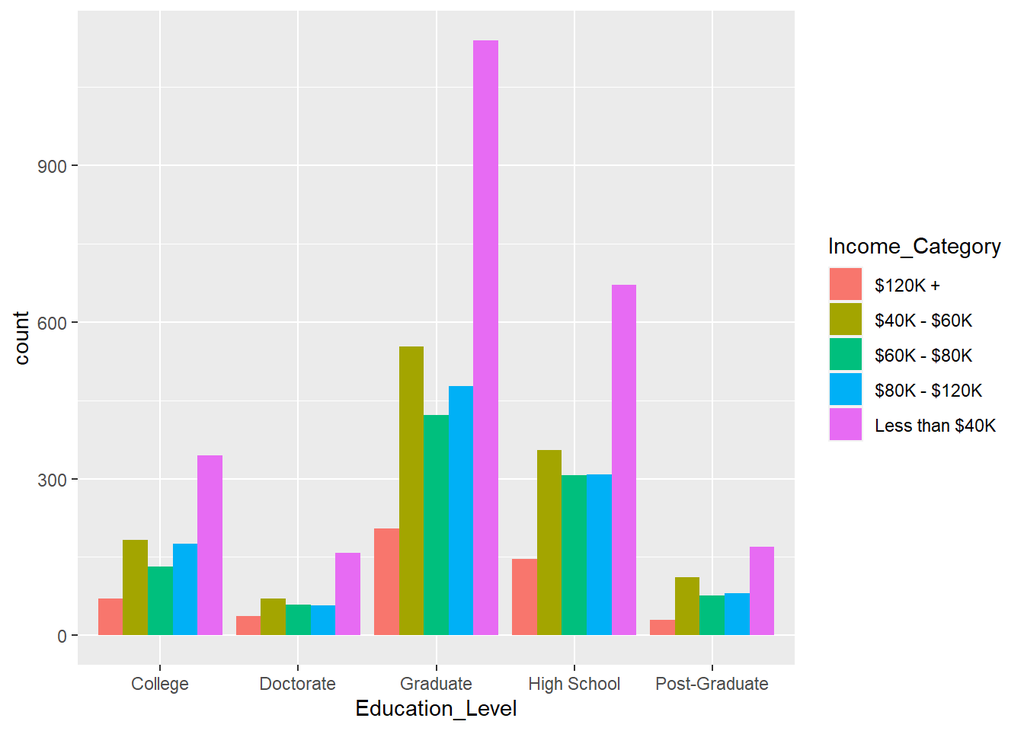

```r
ggplot(data = customer_clean, mapping = aes(x = Education_Level, y = ..count..)) +
  geom_bar(mapping = aes(fill = Income_Category),
           position = "dodge")
```

- Dari hasil visualisasi histogram pada bagian Credit Limit, kita dapat mengetahui bahwa mayoritas customer kita memiliki limit dibawah 5000USD dan semakin tinggi limitnya, semakin sedikit juga penggunanya. Akan tetapi, tedapat peningkatan jumlah pengguna kartu kredit ketika limitnya mencari di angka 33-35 ribu USD.

Untuk melakukan analisa lebih mendetail terhadap temuan tersebut, kita akan mencoba melihat secara lebih spesifik terhadap customer yang memiliki credit limit direntang 33-35rb USD.

```r
customer_clean %>%
  filter(Credit_Limit > 33000) %>%
  summary()
```

```
#>   Customer_Age   Gender       Education_Level  Marital_Status
#>  Min.   :27.00   F:  0   College      : 59    Divorced: 28
#>  1st Qu.:43.00   M:354   Doctorate    : 18    Married :134
#>  Median :48.00           Graduate     :157    Single  :165
#>  Mean   :46.92           High School  : 93    Unknown : 27
#>  3rd Qu.:52.00           Post-Graduate: 27
#>  Max.   :62.00
#>        Income_Category Months_Inactive_12_mon  Credit_Limit   Total_Trans_Amt
#>  $120K +       :140    Min.   :1.000          Min.   :33122   Min.   :  691
#>  $40K - $60K   :  0    1st Qu.:2.000          1st Qu.:34516   1st Qu.: 2311
#>  $60K - $80K   : 45    Median :2.000          Median :34516   Median : 4263
#>  $80K - $120K  :169    Mean   :2.299          Mean   :34467   Mean   : 6156
#>  Less than $40K:  0    3rd Qu.:3.000          3rd Qu.:34516   3rd Qu.: 8184
#>                        Max.   :6.000          Max.   :34516   Max.   :16692
#>  Total_Trans_Ct
#>  Min.   : 12.00
#>  1st Qu.: 52.00
#>  Median : 72.00
#>  Mean   : 72.24
#>  3rd Qu.: 92.00
#>  Max.   :132.00
```

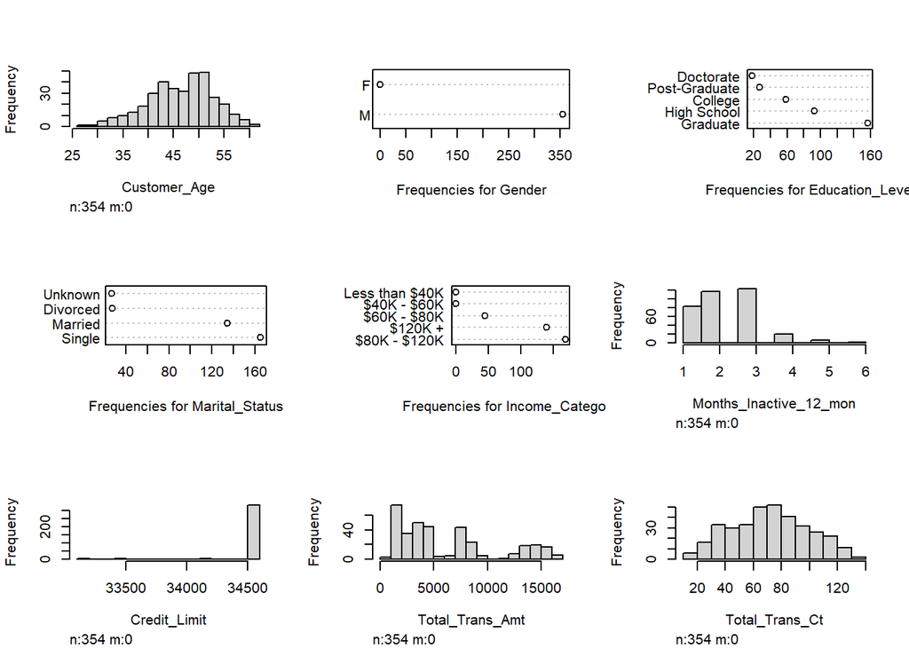

```r
customer_clean %>%
  filter(Credit_Limit > 33000) %>%
  hist.data.frame()
```

# 3 Clustering

Clustering adalah salah satu teknik Machine Learning, yang memiliki kemampuan untuk *mengelompokkan kumpulan data yang tidak berlabel*. Setiap data yang tidak berlabel nantinya akan diklasifikasikan ke dalam kelompok tertentu dimana, titik data yang berada dalam kelompok yang sama akan memiliki sifat atau fitur yang serupa, sedangkan titik data dalam kelompok yang berbeda diharapkan memiliki sifat atau fitur yang sangat berbeda.

Dalam ilmu data, kita dapat menggunakan clustering untuk mendapatkan beberapa wawasan berharga dari data kita dengan melihat hasil pengelompokan yang terjadi. Informasi yang berharga tersebut bisa kita bawa untuk membantu kita dalam menentukan segmentasi market, social netwrok analysis, dan masih banyak lagi. Dalam kasus ini kita akan memanfatkannya untuk melakuakan segmentasi customer.

## 3.1 Implementasi Clustering

- Perhitungan jarak antar observasi data
- Penentuan jumlah cluster
- Pembuatan cluster
- Interpretasi

### 3.1.1 Perhitungan jarak antar observasi data

Dari hasil eksplorasi data, kita mengetahui bahwa total observasi data kita adalah lebih dari 6.000 baris dan setiap observasi data pastinya memiliki nilai yang berbeda. Agar nantinya hasil dari setiap kelompok terdiri dari data-data yang identik, kita harus mengetahui jarak antara satu observasi dengan observasi lainnya berdekatan atau tidak

Di R, terdapat sebuah metode yang dapat kita manfaatkan untuk menghitung seberapa dekat satu observasi terhadap observasi lainnya. Metode tersebut dinamakan *Gower Distance*, metode Gower Distance tersimpan pada `library(cluster)` dan fungsi yang bisa digunakan adalah `daisy()` Pada fungsi tersebut nantinya akan ada 2 parameter yang bisa diisi, yaitu:

- `x`: Data frame yang ingin digunakan
- `metric`: Metode apa yang ingin digunakan, karena kita akan menggunakan metode Gower Distance, kita bisa isi dengan **“gower”**.

```r
customer_gd <- daisy(x = customer_clean,
                     metric = "gower")
```

kita bisa mencetak pasangan yang paling mirip dan berbeda dalam data kita dengan menggunakan fungsi di bawah ini.

- Contoh pasangan data yang paling identik

```r
# Please run the code down below
example <- as.matrix(customer_gd)

customer_clean[which(example == min(example[example != min(example)]),
        arr.ind = TRUE)[1, ], ]
```

|  | Customer_Age | Gender | Education_Level | Marital_Status | Income_Category | Months_Inactive_12_mon | Credit_Limit | Total_Trans_Amt | Total_Trans_Ct |
| --- | --- | --- | --- | --- | --- | --- | --- | --- | --- |
| 717651333 | 55 | F | Graduate | Single | Less than $40K | 3 | 1745 | 4562 | 67 |
| 771092433 | 55 | F | Graduate | Single | Less than $40K | 3 | 1724 | 4434 | 67 |

- Contoh pasangan data yang paling tidak identik

```r
# Please run the code down below
customer_clean[which(example == max(example[example != max(example)]),
        arr.ind = TRUE)[1, ], ]
```

|  | Customer_Age | Gender | Education_Level | Marital_Status | Income_Category | Months_Inactive_12_mon | Credit_Limit | Total_Trans_Amt | Total_Trans_Ct |
| --- | --- | --- | --- | --- | --- | --- | --- | --- | --- |
| 719324658 | 27 | M | College | Unknown | $80K - $120K | 1 | 34516 | 14716 | 112 |
| 771693933 | 62 | F | Graduate | Married | Less than $40K | 6 | 2802 | 1757 | 33 |

### 3.1.2 Penentuan Jumlah Cluster

Seperti yang sudah disampaikan pada bagian pendahuluan, tujuan dari melakukan clustering adalah menempatkan setiap observasi data yang ada ke beberapa kelompok yang sesuai dengan karakteristiknya atau bedasarkan kedekatan jarak antar setiap observasi. Pada langkah pertama kita sudah memiliki informasi jarak antar setiap observasi, kita akan memanfaatkan informasi tersebut untuk menentukan berapakah kelompok yang paling optimal. Hasil dari jumlah kelompok nantinya akan digunakan untuk menentukan berapa banyak segmentasi kustomer yang bisa dibuat berdasarkan data historis pembelian kustomer.

Dalam menentukan jumlah kelompok yang paling optimum, kita data memanfaatkan metode *Elbow Method*. Hasil dari elbow method ini akan menghasilkan rekomendasi kelompok yang diangap paling optimum untuk digunakan.

Metode Elbow dapat kita gunakan dengan fungsi `fviz_nbclust()` dari `library(factoextra)`. Pada fungsi tersebut nantinya akan ada 3 parameter yang bisa diisi, yaitu:

- `x` = data yang akan kita gunakan
- `FUNcluster` = metode cluster yang akan kita gunakan
- `method` = metode penentuan jumlah cluster yang akan digunakan

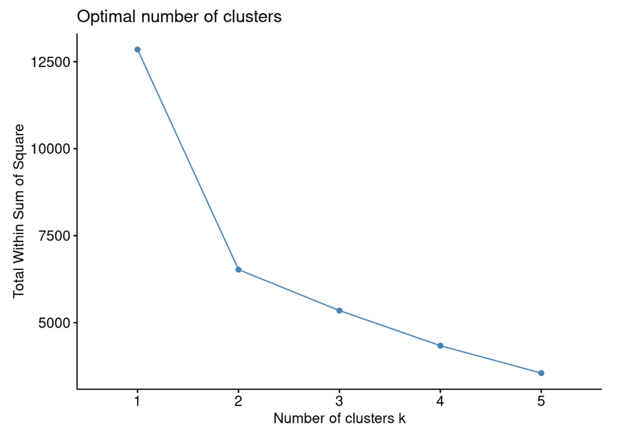

```r
# Please type your code
set.seed(123)

elbow_method <- fviz_nbclust(x = as.matrix(customer_gd),
             FUNcluster = pam,
             method = "wss",
             k.max = 5)
```

Dari hasil visualisasi di atas, kita data berasumsi bahwa K = 2 karea kita dapat melihat pada titik manakah penurunan WSS tidak terlalu signifikan, pada titik itulah nantinya kita akan manfaatkan sebagai jumlah kelompok yang paling ideal.

Dislaimer: Penentuan jumlah kelompok tidak wajib menggunakan metode pengujian di atas, penentuan kelompok juga dapat ditentukan berdasarkan pertanyaan bisnis atau kesepakatan bersama.

### 3.1.3 Pembuatan Cluster

Sekarang kita bisa memulai tahapan terakhir yaitu mengelompokan semua data customer ke kelompok yang sudah ditentukan dengan menggunakan fungsi `pam()`. Pada fungsi tersebut nantinya akan ada 2 parameter yang bisa diisi, yaitu:

- `x` = Data frame yang ingin digunakan
- `k` = Jumlah kelompok

```r
# Please type your code
pam_fit <- pam(x = customer_gd,
               k = 2)
```

### 3.1.4 Interpretasi

#### 3.1.4.1 Metode Visualisasi

Jika dengan menggunakan metode statistik deskriptif kita bisa memahami karakteristik dari masing-masing kelompok, metode visualisasi dapat membantu kita untuk menilai bagaimana hasil pengelompokan. Metode visualisasi yang akan digunakan adalah metode t-SNE, metode ini merupakan salah satu cara untuk memvisualisasikan data yang tidak hanya memiliki nilai numerik saja melainkan nilai kategorikal juga.

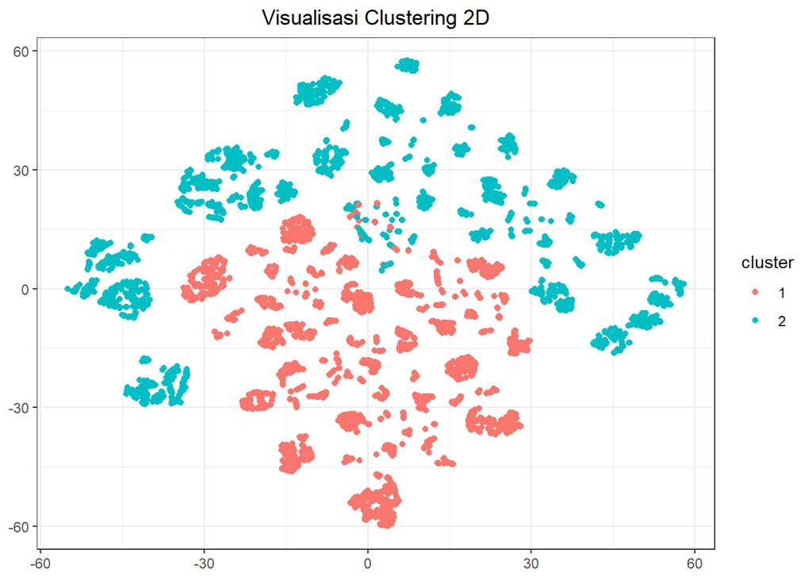

```r
# Please type your code
set.seed(123)

tsne_obj <- Rtsne(X = customer_gd,
                  is_distance = TRUE)

tsne_data <- tsne_obj$Y %>%
  data.frame() %>%
  setNames(c("X", "Y")) %>%
  mutate(cluster = factor(pam_fit$clustering))

ggplot(aes(x = X, y = Y), data = tsne_data) +
  geom_point(aes(color = cluster)) +
  labs(title = "Visualisasi Clustering 2D") +
  theme_bw() +
  theme(plot.title = element_text(hjust = 0.5),
        axis.title = element_blank())
```

#### 3.1.4.2 Metode Deskriptif

Tujuan melakukan statistik deskriptif adalah untuk memahami karakteristik masing-masing kelompok, dan dalam kasus ini untuk mengetahui karakteristik untuk setiap segmentasi kustomer.

```r
# Please type your code
pam_results <- customer_clean %>%
  mutate(cluster = pam_fit$clustering) %>%
  group_by(cluster) %>%
  do(the_summary = summary(.))
```

*Cluster 1:*

```r
pam_results$the_summary[[1]]
```

```
#>   Customer_Age   Gender        Education_Level  Marital_Status
#>  Min.   :26.00   F:   0   College      : 461   Divorced: 224
#>  1st Qu.:41.00   M:3167   Doctorate    : 182   Married :1511
#>  Median :46.00            Graduate     :1355   Single  :1191
#>  Mean   :46.16            High School  : 929   Unknown : 241
#>  3rd Qu.:52.00            Post-Graduate: 240
#>  Max.   :73.00
#>        Income_Category Months_Inactive_12_mon  Credit_Limit   Total_Trans_Amt
#>  $120K +       : 488   Min.   :0.000          Min.   : 1438   Min.   :  530
#>  $40K - $60K   : 546   1st Qu.:2.000          1st Qu.: 4116   1st Qu.: 1870
#>  $60K - $80K   : 997   Median :2.000          Median : 9272   Median : 3547
#>  $80K - $120K  :1099   Mean   :2.332          Mean   :13072   Mean   : 4519
#>  Less than $40K:  37   3rd Qu.:3.000          3rd Qu.:19444   3rd Qu.: 4766
#>                        Max.   :6.000          Max.   :34516   Max.   :17995
#>  Total_Trans_Ct      cluster
#>  Min.   : 10.00   Min.   :1
#>  1st Qu.: 42.00   1st Qu.:1
#>  Median : 64.00   Median :1
#>  Mean   : 63.26   Mean   :1
#>  3rd Qu.: 80.00   3rd Qu.:1
#>  Max.   :132.00   Max.   :1
```

Characteristic:

- Gender hanya Male saja
- Untuk tingkat edukasinya mayoritas adalah Graduate
- Marital statusya paling banyak adalah Married
- Mayoritas tingkat penghasilan cukup tinggi, berada di rentan 80-120K USD
- Credit limit memiliki rentang 1500 - 34500 USD dengan nilai median di angka 9000 USD
- Total transaksi dalam bentuk nominal memiliki rentan 530 - 18000 USD dengan nilai media di angka 3500 USD
- Total transkasi dalam bentuk jumlah pembelian memiliki rentan 10 - 132 dengan nilai median di angka 64

*Cluster 2:*

```r
pam_results$the_summary[[2]]
```

```
#>   Customer_Age   Gender        Education_Level  Marital_Status
#>  Min.   :26.00   F:3008   College      : 444   Divorced: 231
#>  1st Qu.:41.00   M: 164   Doctorate    : 199   Married :1475
#>  Median :46.00            Graduate     :1441   Single  :1245
#>  Mean   :46.39            High School  : 859   Unknown : 221
#>  3rd Qu.:52.00            Post-Graduate: 229
#>  Max.   :70.00
#>        Income_Category Months_Inactive_12_mon  Credit_Limit   Total_Trans_Amt
#>  $120K +       :   0   Min.   :0.000          Min.   : 1438   Min.   :  510
#>  $40K - $60K   : 726   1st Qu.:2.000          1st Qu.: 2048   1st Qu.: 2349
#>  $60K - $80K   :   0   Median :2.000          Median : 2873   Median : 4105
#>  $80K - $120K  :   0   Mean   :2.354          Mean   : 3914   Mean   : 4273
#>  Less than $40K:2446   3rd Qu.:3.000          3rd Qu.: 4489   3rd Qu.: 4747
#>                        Max.   :6.000          Max.   :23981   Max.   :17437
#>  Total_Trans_Ct      cluster
#>  Min.   : 13.00   Min.   :2
#>  1st Qu.: 47.00   1st Qu.:2
#>  Median : 69.00   Median :2
#>  Mean   : 65.86   Mean   :2
#>  3rd Qu.: 81.00   3rd Qu.:2
#>  Max.   :131.00   Max.   :2
```

Business Plan:

- Jika dilihat walaupun income dari cluster ke 2 lebih rendah dibandingkan dengan cluster 1, akan tetapi untuk amount transaksinya kurang lebih sama. Maka dari itu kita bisa memberikan promo-promo untuk barang yang tidak terlalu premium agar customer tersebut bisa tetap melakukan pembelian.
- Ketika tim kita menawarkan kartu kredit dan ada customer yang bertanya, kira-kira berapa limit kartu kredit yang direkomendasikan? Kita bisa memberikan saran berdasarkan kategori incomenya.
  - Untuk calon customer dengan gaji dengan rentang dibawah 60K USD, kita bisa memberikan saran untuk membuka KK dengan limit 3000-4000 USD berdasarkan karakterisitik dari cluster 2
  - Untuk calon customer dengan gaji dengan rentang diatas 60K USD, kita bisa memberikan saran untuk membuka KK dengan limit 10.000 USD berdasarkan karakterisitik dari cluster 1